# RMarkdown: Write for Science!

Michael A Barrowman

28/04/2020

# 1 Introduction

Have you ever tried moving a table in Word? How about inserting an image into Google Docs? Switching between your stats program and report becoming a nightmare? Do you hate citations (Reference 2020)?

# 2 What can we do?

This course will help you to transition smoothly into the world of RMarkdown, where you can do your statistical analysis and write your entire report/essay in a single document! RMarkdown takes care of things like formatting and figure/table placement for you without worrying about the nitty gritty.

Table 2.1: Here’s some data!

| x | y |
| --- | --- |
| 0.850 | 0.548 |
| 0.515 | 0.362 |
| 0.270 | 0.907 |
| 0.569 | 0.636 |
| 0.391 | 0.120 |
| 0.090 | 0.374 |

# 3 What can we make?

RMarkdown also unifies your output: Word, PDF and Webpage. It can also produce Presentations and Posters all from a singe document with the touch of a button. Cross-Refencing is a breeze, as can be seen in 2.1 and 3.1.

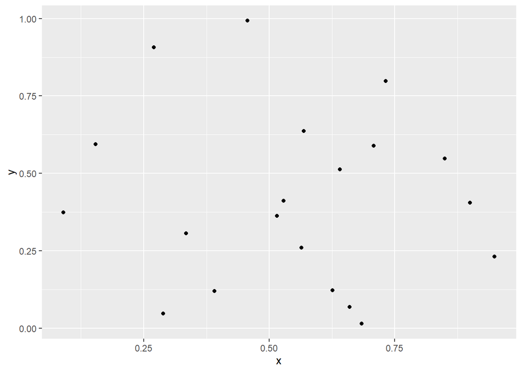

Figure 3.1: Plots are easy!

# 4 How?

We combine elements of R (the statistical package) and Markdown (the way you format comments on forums like Reddit) into one system and *knit* them into a document. For an example of what you’ll be able to produce after this session, see here::

- HTML A html version of this file
- PDF A pdf version of this file
- Word A Word version of this file

# References

Reference, Mr A. 2020. “I Hate Reference: How to Cite in Rmarkdown.”